# Preprocess

## Dataset

[New York Citi Bike Trip Histories](https://www.citibikenyc.com/system-data)

Use 201707-citibike-tripdata.csv.zip as dataset

## Schema

- Trip Duration (seconds)
- Start Time and Date
- Stop Time and Date
- Start Station Name
- End Station Name
- Station ID
- Station Lat/Long
- Bike ID
- User Type (Customer = 24-hour pass or 3-day pass user; Subscriber = Annual Member)
- Gender (Zero=unknown; 1=male; 2=female)
- Year of Birth

This data has been processed to remove trips that are taken by staff as they service and inspect the system, trips that are taken to/from any of our “test” stations (which we were using more in June and July 2013), and any trips that were below 60 seconds in length (potentially false starts or users trying to re-dock a bike to ensure it's secure).

### Import packages

```python
import pandas as pd
import numpy as np
import matplotlib.pyplot as plt
import plotly.plotly as py
from datetime import datetime
from plotly.graph_objs import *
from geopy.distance import great_circle
from sklearn.metrics.pairwise import euclidean_distances
from scipy import signal
%matplotlib inline
```

### Read csv to dataframe

use pandas to read data

```python
df = pd.read_csv('./201707-citibike-tripdata.csv')
df.head()
```

|  | tripduration | starttime | stoptime | start station id | start station name | start station latitude | start station longitude | end station id | end station name | end station latitude | end station longitude | bikeid | usertype | birth year | gender |
| --- | --- | --- | --- | --- | --- | --- | --- | --- | --- | --- | --- | --- | --- | --- | --- |
| 0 | 364 | 2017-07-01 00:00:00 | 2017-07-01 00:06:05 | 539 | Metropolitan Ave & Bedford Ave | 40.715348 | -73.960241 | 3107 | Bedford Ave & Nassau Ave | 40.723117 | -73.952123 | 14744 | Subscriber | 1986.0 | 1 |
| 1 | 2142 | 2017-07-01 00:00:03 | 2017-07-01 00:35:46 | 293 | Lafayette St & E 8 St | 40.730207 | -73.991026 | 3425 | 2 Ave & E 104 St | 40.789210 | -73.943708 | 19587 | Subscriber | 1981.0 | 1 |
| 2 | 328 | 2017-07-01 00:00:08 | 2017-07-01 00:05:37 | 3242 | Schermerhorn St & Court St | 40.691029 | -73.991834 | 3397 | Court St & Nelson St | 40.676395 | -73.998699 | 27937 | Subscriber | 1984.0 | 2 |
| 3 | 2530 | 2017-07-01 00:00:11 | 2017-07-01 00:42:22 | 2002 | Wythe Ave & Metropolitan Ave | 40.716887 | -73.963198 | 398 | Atlantic Ave & Furman St | 40.691652 | -73.999979 | 26066 | Subscriber | 1985.0 | 1 |
| 4 | 2534 | 2017-07-01 00:00:15 | 2017-07-01 00:42:29 | 2002 | Wythe Ave & Metropolitan Ave | 40.716887 | -73.963198 | 398 | Atlantic Ave & Furman St | 40.691652 | -73.999979 | 29408 | Subscriber | 1982.0 | 2 |

```python
df.info()
```

```
<class 'pandas.core.frame.DataFrame'>
RangeIndex: 1735599 entries, 0 to 1735598
Data columns (total 15 columns):
tripduration               int64
starttime                  object
stoptime                   object
start station id           int64
start station name         object
start station latitude     float64
start station longitude    float64
end station id             int64
end station name           object
end station latitude       float64
end station longitude      float64
bikeid                     int64
usertype                   object
birth year                 float64
gender                     int64
dtypes: float64(5), int64(5), object(5)
memory usage: 198.6+ MB
```

## Detect missing data

find out some null or NAN in dataframe, and we find NAN in birth year column

```python
df.isnull().sum()
```

```
tripduration                    0
starttime                       0
stoptime                        0
start station id                0
start station name              0
start station latitude          0
start station longitude         0
end station id                  0
end station name                0
end station latitude            0
end station longitude           0
bikeid                          0
usertype                        0
birth year                 228596
gender                          0
dtype: int64
```

### Fill missing data with the most frequency data

because birth year is not like real number, we do not use mean to fill missing data; using the most frequency data is more proper to fix it

```python
df['birth year'] = df['birth year'].fillna(df['birth year'].mode()[0])
df.isnull().sum()
```

```
tripduration               0
starttime                  0
stoptime                   0
start station id           0
start station name         0
start station latitude     0
start station longitude    0
end station id             0
end station name           0
end station latitude       0
end station longitude      0
bikeid                     0
usertype                   0
birth year                 0
gender                     0
dtype: int64
```

## Detect strange data

detect and fix thhe data

```python
df.describe()
```

|  | tripduration | start station id | start station latitude | start station longitude | end station id | end station latitude | end station longitude | bikeid | birth year | gender |
| --- | --- | --- | --- | --- | --- | --- | --- | --- | --- | --- |
| count | 1.735599e+06 | 1.735599e+06 | 1.735599e+06 | 1.735599e+06 | 1.735599e+06 | 1.735599e+06 | 1.735599e+06 | 1.735599e+06 | 1.735599e+06 | 1.735599e+06 |
| mean | 1.060143e+03 | 1.371501e+03 | 4.073562e+01 | -7.398510e+01 | 1.370967e+03 | 4.073536e+01 | -7.398519e+01 | 2.317056e+04 | 1.980699e+03 | 1.095545e+00 |
| std | 9.622457e+03 | 1.348571e+03 | 2.859067e-02 | 1.744022e-02 | 1.348952e+03 | 2.855812e-02 | 1.747490e-02 | 4.988904e+03 | 1.114420e+01 | 5.978624e-01 |
| min | 6.100000e+01 | 7.200000e+01 | 4.065540e+01 | -7.401713e+01 | 7.200000e+01 | 4.065540e+01 | -7.406692e+01 | 1.452900e+04 | 1.874000e+03 | 0.000000e+00 |
| 25% | 3.950000e+02 | 3.590000e+02 | 4.071740e+01 | -7.399725e+01 | 3.590000e+02 | 4.071723e+01 | -7.399726e+01 | 1.840200e+04 | 1.974000e+03 | 1.000000e+00 |
| 50% | 6.760000e+02 | 4.860000e+02 | 4.073625e+01 | -7.398765e+01 | 4.850000e+02 | 4.073588e+01 | -7.398766e+01 | 2.519100e+04 | 1.985000e+03 | 1.000000e+00 |
| 75% | 1.183000e+03 | 3.142000e+03 | 4.075514e+01 | -7.397575e+01 | 3.141000e+03 | 4.075510e+01 | -7.397605e+01 | 2.773400e+04 | 1.988000e+03 | 1.000000e+00 |
| max | 2.477222e+06 | 3.478000e+03 | 4.088092e+01 | -7.389660e+01 | 3.478000e+03 | 4.088092e+01 | -7.389660e+01 | 3.033700e+04 | 2.001000e+03 | 2.000000e+00 |

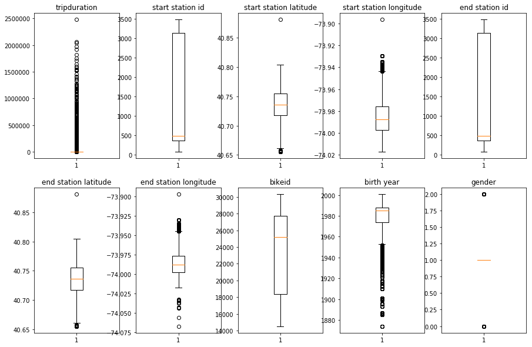

```python
def show_box():
    fig, axes = plt.subplots(nrows = 2, ncols = 5, figsize = (15,10))
    i = 1
    for col in df.columns:
        if df[col].dtype == np.float64 or df[col].dtype == np.int64:
            ax = plt.subplot(2, 5, i)
            plt.boxplot(df[col])
            ax.set_title(col)
            i += 1
    plt.show()

show_box()
```

### Remove strange data

- tripduration
  - The time exceed a week could be forgot to return
- birth year < 1917
  - The 100-year-old people are alomst impossible to ride bike

```python
df = df.drop(df[df['tripduration'] > 7 * 86400].index)
df = df.drop(df[df['birth year'] < 1917].index)
```

### Detect unique station id map to station name

```python
x1 = len(df['start station id'].unique())
y1 = len(df[['start station id', 'start station name']].drop_duplicates())
x2 = len(df['end station id'].unique())
y2 = len(df[['end station id', 'end station name']].drop_duplicates())

x1 == y1 and x2 == y2
```

```
True
```

### Detect unique station id map to station latitude

```python
x1 = len(df['start station id'].unique())
y2 = len(df[['start station id', 'start station latitude']].drop_duplicates())
x2 = len(df['end station id'].unique())
y2 = len(df[['end station id', 'end station latitude']].drop_duplicates())

x1 == y1 and x2 == y2
```

```
True
```

### Detect unique station id map to station longitude

```python
x1 = len(df['start station id'].unique())
y2 = len(df[['start station id', 'start station longitude']].drop_duplicates())
x2 = len(df['end station id'].unique())
y2 = len(df[['end station id', 'end station longitude']].drop_duplicates())

x1 == y1 and x2 == y2
```

```
True
```

### Final dataframe

More clear and easy to analyze

```
1735018
```

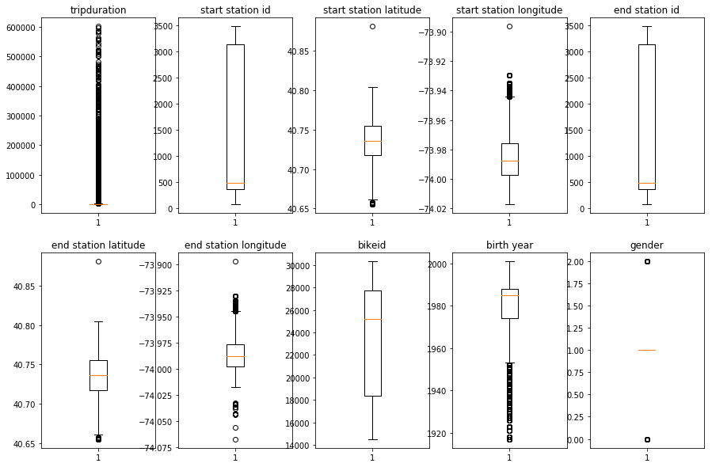

```python
print len(df)
show_box()
```

### Plot stations in google map

[figure not shown]

## Translate time to every half hour stamp and detect strange time

```python
def timestamp(df):
    tmp = []
    t0 = datetime(2017, 7, 1, 0, 0)
    for row in df.itertuples():
        t1 = datetime.strptime(row[1], '%Y-%m-%d %H:%M:%S')
        tm = int((t1 - t0).total_seconds() // 1800)
        assert tm >= 0
        tmp.append(tm)
    df.insert(loc = 0, column = 'timestamp', value = tmp)

start_df = df[['starttime', 'start station id']]
timestamp(start_df)
end_df = df[['stoptime', 'end station id']]
timestamp(end_df)
start_df.head()
```

|  | timestamp | starttime | start station id |
| --- | --- | --- | --- |
| 0 | 0 | 2017-07-01 00:00:00 | 539 |
| 1 | 0 | 2017-07-01 00:00:03 | 293 |
| 2 | 0 | 2017-07-01 00:00:08 | 3242 |
| 3 | 0 | 2017-07-01 00:00:11 | 2002 |
| 4 | 0 | 2017-07-01 00:00:15 | 2002 |

```python
end_df.head()
```

|  | timestamp | stoptime | end station id |
| --- | --- | --- | --- |
| 0 | 0 | 2017-07-01 00:06:05 | 3107 |
| 1 | 1 | 2017-07-01 00:35:46 | 3425 |
| 2 | 0 | 2017-07-01 00:05:37 | 3397 |
| 3 | 1 | 2017-07-01 00:42:22 | 398 |
| 4 | 1 | 2017-07-01 00:42:29 | 398 |

## Calculate station number

append two columns and put them into set, so we can use len function to know the station number

```python
station_id = list(set(df['start station id'].tolist() + df['end station id'].tolist()))
station_num = len(station_id)
station_num
```

```
634
```

## Calculate in_flow and out_flow

use end_df and start_df to sum every timestamp, and the outcome is in_flow and out_flow

```python
def cnt_flow(df):
    flow = pd.DataFrame(np.zeros((48 * 31, station_num)), columns = station_id)
    for row in df.itertuples():
        if row[1] < 48 * 31:
            flow.loc[row[1], row[3]] += 1
    return flow

in_flow = cnt_flow(end_df)
out_flow = cnt_flow(start_df)
in_flow.to_csv('in_flow.csv')
out_flow.to_csv('out_flow.csv')
in_flow.head()
```

|  | 72 | 79 | 82 | 83 | 116 | 119 | 120 | 127 | 128 | 143 | ... | 2003 | 2005 | 2006 | 2008 | 2009 | 2010 | 2012 | 2021 | 2022 | 2023 |
| --- | --- | --- | --- | --- | --- | --- | --- | --- | --- | --- | --- | --- | --- | --- | --- | --- | --- | --- | --- | --- | --- |
| 0 | 1.0 | 1.0 | 0.0 | 0.0 | 0.0 | 0.0 | 0.0 | 0.0 | 1.0 | 0.0 | ... | 0.0 | 0.0 | 0.0 | 3.0 | 1.0 | 0.0 | 1.0 | 0.0 | 0.0 | 0.0 |
| 1 | 0.0 | 0.0 | 0.0 | 0.0 | 0.0 | 0.0 | 0.0 | 2.0 | 1.0 | 0.0 | ... | 1.0 | 0.0 | 0.0 | 2.0 | 0.0 | 1.0 | 0.0 | 2.0 | 0.0 | 1.0 |
| 2 | 2.0 | 0.0 | 0.0 | 0.0 | 0.0 | 0.0 | 1.0 | 2.0 | 1.0 | 0.0 | ... | 0.0 | 0.0 | 0.0 | 1.0 | 0.0 | 1.0 | 1.0 | 0.0 | 0.0 | 0.0 |
| 3 | 0.0 | 1.0 | 0.0 | 0.0 | 2.0 | 0.0 | 0.0 | 0.0 | 0.0 | 0.0 | ... | 2.0 | 0.0 | 0.0 | 1.0 | 0.0 | 0.0 | 0.0 | 0.0 | 0.0 | 0.0 |
| 4 | 0.0 | 0.0 | 0.0 | 0.0 | 0.0 | 0.0 | 0.0 | 1.0 | 2.0 | 1.0 | ... | 1.0 | 0.0 | 1.0 | 0.0 | 0.0 | 0.0 | 0.0 | 0.0 | 0.0 | 0.0 |

5 rows × 634 columns

```python
out_flow.head()
```

|  | 72 | 79 | 82 | 83 | 116 | 119 | 120 | 127 | 128 | 143 | ... | 2003 | 2005 | 2006 | 2008 | 2009 | 2010 | 2012 | 2021 | 2022 | 2023 |
| --- | --- | --- | --- | --- | --- | --- | --- | --- | --- | --- | --- | --- | --- | --- | --- | --- | --- | --- | --- | --- | --- |
| 0 | 0.0 | 0.0 | 0.0 | 0.0 | 1.0 | 0.0 | 0.0 | 1.0 | 3.0 | 0.0 | ... | 0.0 | 0.0 | 1.0 | 3.0 | 0.0 | 0.0 | 0.0 | 1.0 | 0.0 | 0.0 |
| 1 | 0.0 | 0.0 | 0.0 | 1.0 | 1.0 | 0.0 | 1.0 | 1.0 | 4.0 | 0.0 | ... | 0.0 | 0.0 | 0.0 | 0.0 | 0.0 | 0.0 | 0.0 | 1.0 | 0.0 | 0.0 |
| 2 | 1.0 | 1.0 | 0.0 | 2.0 | 0.0 | 0.0 | 2.0 | 0.0 | 2.0 | 0.0 | ... | 0.0 | 0.0 | 0.0 | 2.0 | 0.0 | 0.0 | 0.0 | 1.0 | 0.0 | 0.0 |
| 3 | 1.0 | 2.0 | 0.0 | 0.0 | 0.0 | 0.0 | 0.0 | 0.0 | 1.0 | 0.0 | ... | 2.0 | 0.0 | 0.0 | 0.0 | 0.0 | 1.0 | 0.0 | 1.0 | 0.0 | 1.0 |
| 4 | 0.0 | 2.0 | 0.0 | 0.0 | 1.0 | 0.0 | 2.0 | 0.0 | 0.0 | 0.0 | ... | 0.0 | 0.0 | 0.0 | 0.0 | 0.0 | 0.0 | 1.0 | 0.0 | 0.0 | 0.0 |

5 rows × 634 columns

# Query

## 1. How many stations are there in this dataset, and what is the average distance between them?

there are 634 stations and the average distance between them is 5438.88993843 meters

```python
start_station = df[['start station id', 'start station name', 'start station latitude', 'start station longitude']]
start_station.columns = ['station id', 'station name', 'station latitude', 'station logitude']
end_station = df[['end station id', 'end station name', 'end station latitude', 'end station longitude']]
end_station.columns = ['station id', 'station name', 'station latitude', 'station logitude']

station = start_station.append(end_station, ignore_index = True)
station = station.drop_duplicates()
station = station.reset_index(drop = True)
station_num = len(station)
station.head()
```

|  | station id | station name | station latitude | station logitude |
| --- | --- | --- | --- | --- |
| 0 | 539 | Metropolitan Ave & Bedford Ave | 40.715348 | -73.960241 |
| 1 | 293 | Lafayette St & E 8 St | 40.730207 | -73.991026 |
| 2 | 3242 | Schermerhorn St & Court St | 40.691029 | -73.991834 |
| 3 | 2002 | Wythe Ave & Metropolitan Ave | 40.716887 | -73.963198 |
| 4 | 361 | Allen St & Hester St | 40.716059 | -73.991908 |

### use great circle to calculate distance

to calculate the distance between stations, using the function great circle in package GeoPy

```python
dist_sum = 0
for i in xrange(station_num):
    for j in xrange(station_num):
        a = (station.iloc[i, 2], station.iloc[i, 3])
        b = (station.iloc[j, 2], station.iloc[j, 3])
        dist_sum += great_circle(a, b).meters

print dist_sum / float(station_num * (station_num - 1) / 2) / 2 # divide two again because we calculate (a, b) and (b, a)
```

```
5438.88993843
```

## 2. What are the top 3 frequent stations pairs (start stations, end stations) in weekdays, how about in weekends?

represent station by station id

- weekdays
  1. (432, 3263) 656
  2. (2006, 2006) 547
  3. (281, 281) 499
- weekends
  1. (3182, 3182) 889
  2. (3182, 3254) 829
  3. (3254, 3182) 818

```python
pair_station = df[['start station id', 'end station id', 'starttime', 'stoptime']]
pair_station.head()
```

|  | start station id | end station id | starttime | stoptime |
| --- | --- | --- | --- | --- |
| 0 | 539 | 3107 | 2017-07-01 00:00:00 | 2017-07-01 00:06:05 |
| 1 | 293 | 3425 | 2017-07-01 00:00:03 | 2017-07-01 00:35:46 |
| 2 | 3242 | 3397 | 2017-07-01 00:00:08 | 2017-07-01 00:05:37 |
| 3 | 2002 | 398 | 2017-07-01 00:00:11 | 2017-07-01 00:42:22 |
| 4 | 2002 | 398 | 2017-07-01 00:00:15 | 2017-07-01 00:42:29 |

```python
pair = {}
for row in pair_station.itertuples():
    d = datetime.strptime(row[3], '%Y-%m-%d %H:%M:%S')
    d = 'weekday' if d.isoweekday() < 6 else 'weekend'
    if pair.get((row[1], row[2], d)):
        pair[(row[1], row[2], d)] += 1
    else:
        pair[(row[1], row[2], d)] = 1
pair = sorted(pair.items(), key=lambda d: d[1])
end_cnt = 0
day_cnt = 0
for key, val in pair[::-1]:
    if end_cnt >= 3 and day_cnt >= 3:
        break
    if 'weekend' in key and end_cnt < 3:
        end_cnt += 1
        print key, val
    if 'weekday' in key and day_cnt < 3:
        day_cnt += 1
        print key, val
```

```
(3182, 3182, 'weekend') 889
(3182, 3254, 'weekend') 829
(3254, 3182, 'weekend') 818
(432, 3263, 'weekday') 656
(2006, 2006, 'weekday') 547
(281, 281, 'weekday') 499
```

## 3. Find the top 3 stations with highest average out-flow, and top 3 highest average in-flow

represent station by station id

### Top 3 stations with highest average out-flow

```python
mean_out_flow = pd.DataFrame(out_flow.mean().tolist(), station_id, columns = ['average flow'])
mean_out_flow.nlargest(3, 'average flow')
```

|  | average flow |
| --- | --- |
| 519 | 9.981855 |
| 426 | 9.487903 |
| 514 | 8.239919 |

### Top 3 stations with highest average in-flow

```python
mean_in_flow = pd.DataFrame(in_flow.mean().tolist(), station_id, columns = ['average flow'])
mean_in_flow.nlargest(3, 'average flow')
```

|  | average flow |
| --- | --- |
| 426 | 9.942204 |
| 519 | 9.721102 |
| 514 | 8.526882 |

## 4. What is the most popular station (highest average inflow + outflow)?

```python
(mean_in_flow + mean_out_flow).nlargest(1, 'average flow')
```

|  | average flow |
| --- | --- |
| 519 | 19.702957 |

### Define function to plot picture and calculate the distance

```python
def cal_and_draw(in_df, out_df):
    p_in_flow = in_df.tolist()
    p_out_flow = out_df.tolist()
    plt.figure(figsize=(15, 15))
    plt.xlabel('time (per half hour)')
    plt.plot(p_in_flow, label = 'in flow')
    plt.plot(p_out_flow, label = 'out flow')
    plt.legend()
    plt.show()
    print euclidean_distances(np.array(p_in_flow).reshape(1, -1), np.array(p_out_flow).reshape(1, -1))[0][0]
```

### Draw the in-flow(A) and out-flow(B) for that station in a line chart

### Calculate the distance function between A and B with euclidean distance

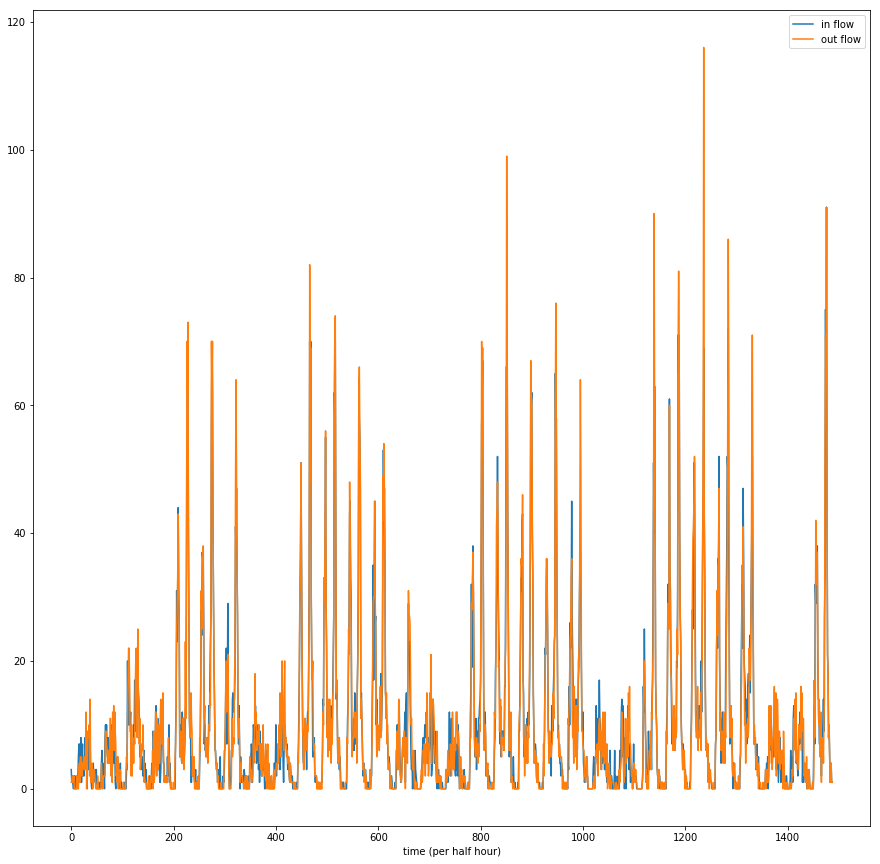

```
178.555313559
```

```python
p_in_flow = in_flow[519]
p_out_flow = out_flow[519]
cal_and_draw(p_in_flow, p_out_flow)
```

### Calculate the distance function between A - mean(A) and B - mean(B) , and draw them both

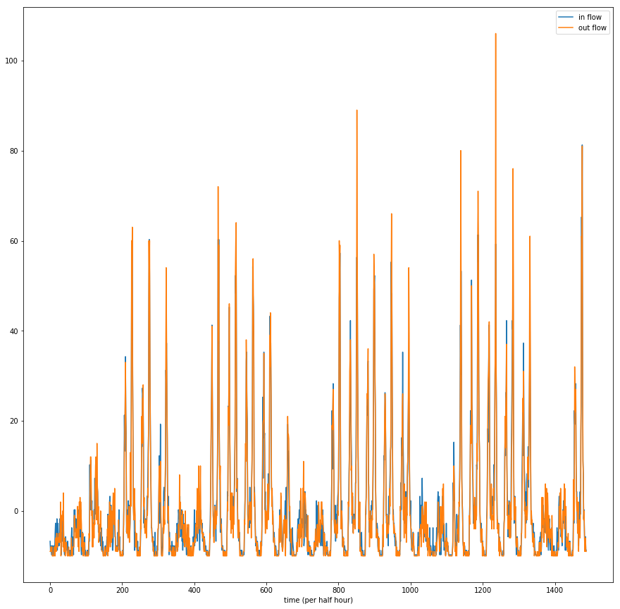

```
178.271781157
```

```python
cal_and_draw(p_in_flow - p_in_flow.mean(), p_out_flow - p_out_flow.mean())
```

### Calculate the distance function between (A - mean(A)) / std(A) and (B - mean(B)) / std(B) , and draw them both

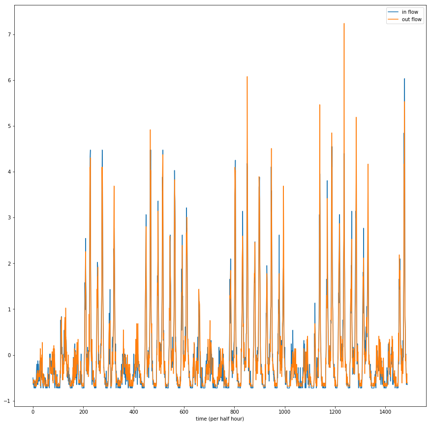

```
12.2746610284
```

```python
cal_and_draw((p_in_flow - p_in_flow.mean()) / p_in_flow.std(), (p_out_flow - p_out_flow.mean()) / p_out_flow.std())
```

### Calculate the distance function between {Ai − f(i) | Ai ∈ A} and {Bi − f(i) | Bi ∈ B} , and draw them both

remove linear trend along axis from data with scipy.signal.detrend

the result of a linear least-squares fit to data is subtracted from data

more usage can find [here](https://docs.scipy.org/doc/scipy-0.19.1/reference/generated/scipy.signal.detrend.html)

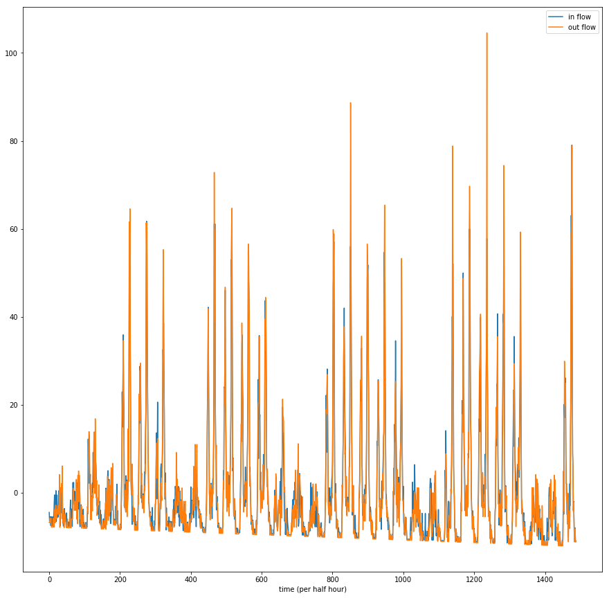

```
178.265612093
```

```python
cal_and_draw(signal.detrend(p_in_flow), signal.detrend(p_out_flow))
```

### Calculate the distance function between Smooth(A) and Smooth(B) , and draw them both

#### Smooth with a Savitzky-Golay filter

a digital filter that can be applied to a set of digital data points for the purpose of smoothing the data, that is, to increase the signal-to-noise ratio without greatly distorting the signal

[figure not shown]

simple version

[figure not shown]

for more usage can find [here](https://docs.scipy.org/doc/scipy-0.16.1/reference/generated/scipy.signal.savgol_filter.html)

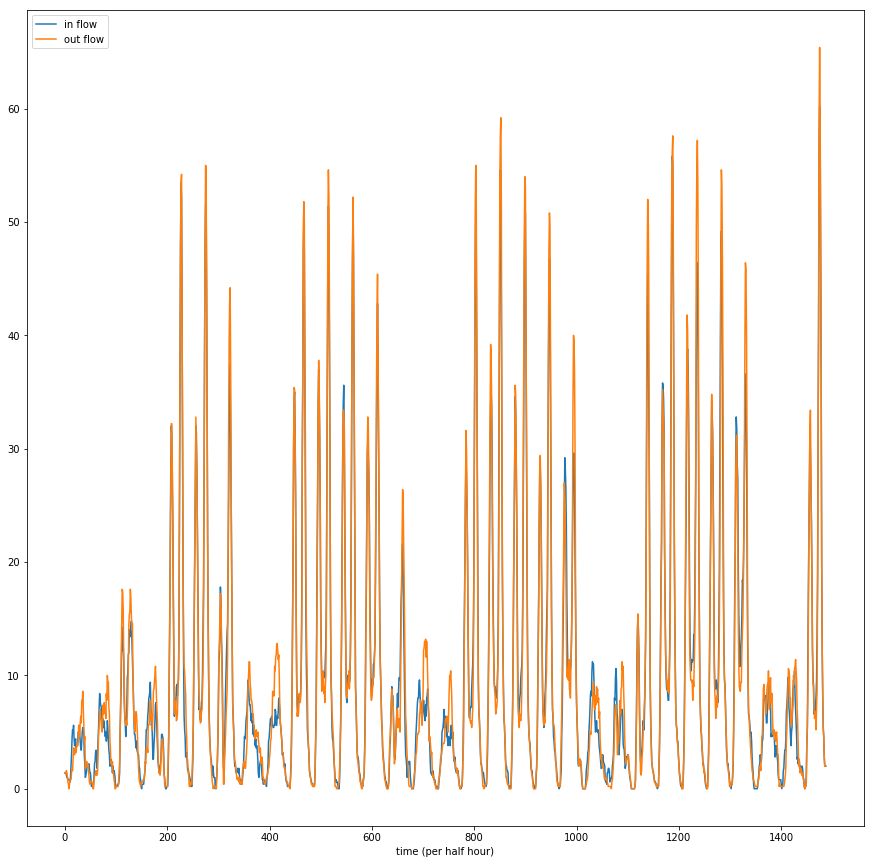

```
85.1213251777
```

```python
cal_and_draw(signal.savgol_filter(p_in_flow, window_length = 5, polyorder = 0), signal.savgol_filter(p_out_flow, window_length = 5, polyorder = 0))
```

## 5. Please try to find some interesting query or observation in the dataset

### Calculate average trip duration with gender

- male 844.315139129 sec
- female 966.405934816 sec
- unknown 1767.73751005 sec

```python
duration_df = df[['tripduration', 'gender']]

male_sum = 0
male = 0
female_sum = 0
female = 0
unknown_sum = 0
unknown = 0

for row in duration_df.itertuples():
    gen = row[2]
    if gen == 0:
        unknown += 1
        unknown_sum += row[1]
    elif gen == 1:
        male += 1
        male_sum += row[1]
    elif gen == 2:
        female += 1
        female_sum += row[1]

print float(male_sum) / float(male)
print float(female_sum) / float(female)
print float(unknown_sum) / float(unknown)
```

```
844.315139129
966.405934816
1767.73751005
```

### The station which is most males and females visited

represent station by station id

in 519 station, there are most males visited in 426 station, there are most females visited, so we can visit there often lol

```python
def keywithmaxval(d):
    v = list(d.values())
    k = list(d.keys())
    return k[v.index(max(v))]

tra_df = df[['start station id', 'end station id', 'gender']]
cnt = {}
cnt2 = {}
for row in tra_df.itertuples():
    if row[3] == 2:
        if cnt.get(row[1]):
            cnt[row[1]] += 1
        else:
            cnt[row[1]] = 1
        if cnt.get(row[2]):
            cnt[row[2]] += 1
        else:
            cnt[row[2]] = 1
    if row[3] == 1:
        if cnt2.get(row[1]):
            cnt2[row[1]] += 1
        else:
            cnt2[row[1]] = 1
        if cnt2.get(row[2]):
            cnt2[row[2]] += 1
        else:
            cnt2[row[2]] = 1
print keywithmaxval(cnt)
print keywithmaxval(cnt2)
```

```
426
519
```

### Observation

- the inflow and outflow in most popular station are very similar after detrend and smooth
- some popular stations are high traffic no matter weekday or weekend
- females' tripduration are higher than males'
- 426 station, West St & Chambers St, is most females visited becourse there are many schools, parks, markets; they can ride bike to somewhere easily

[figure not shown]

- 519 station, Pershing Square North, is most males visited becourse there are many big companies and good public transport; they can ride bike to company and avoid traffic jam

[figure not shown]

- 514 station, 12 Ave & W 40 St, is also many people visited because there are close to New York Line of the Lincoln Tunnel and easily to go to other city

[figure not shown]